# Untitled

Shuhaida

December 16, 2015

```r
train <- read.csv("pml-training.csv")
test <- read.csv("pml-testing.csv")
```

Preprocessing

Partitioning the training set

```r
library(caret)
```

We separate our training data into a training set and a validation set so that we can validate our model.

```r
set.seed(123456)
trainset <- createDataPartition(train$classe, p = 0.8, list = FALSE)
Training <- train[trainset, ]
Validation <- train[-trainset, ]
```

Feature selection

First we clean up near zero variance features, columns with missing values and descriptive fields.

```r
# exclude near zero variance features
nzvcol <- nearZeroVar(Training)
Training <- Training[, -nzvcol]

# exclude columns with m40% ore more missing values exclude descriptive
# columns like name etc
cntlength <- sapply(Training, function(x) {
    sum(!(is.na(x) | x == ""))
})
nullcol <- names(cntlength[cntlength < 0.6 * length(Training$classe)])
descriptcol <- c("X", "user_name", "raw_timestamp_part_1", "raw_timestamp_part_2",
    "cvtd_timestamp", "new_window", "num_window")
excludecols <- c(descriptcol, nullcol)
Training <- Training[, !names(Training) %in% excludecols]
```

Model Train

We will use random forest as our model as implemented in the randomForest package by Breiman’s random forest algorithm (based on Breiman and Cutler’s original Fortran code) for classification and regression.

```r
library(randomForest)
## randomForest 4.6-7
## Type rfNews() to see new features/changes/bug fixes.
rfModel <- randomForest(classe ~ ., data = Training, importance = TRUE, ntrees = 10)
```

Model Validation

Let us now test our model performance on the training set itself and the cross validation set.

Training set accuracy

```r
ptraining <- predict(rfModel, Training)
print(confusionMatrix(ptraining, Training$classe))
```

```
## Confusion Matrix and Statistics
##
##           Reference
## Prediction    A    B    C    D    E
##          A 4464    0    0    0    0
##          B    0 3038    0    0    0
##          C    0    0 2738    0    0
##          D    0    0    0 2573    0
##          E    0    0    0    0 2886
##
## Overall Statistics
##
##                Accuracy : 1
##                  95% CI : (0.9998, 1)
##     No Information Rate : 0.2843
##     P-Value [Acc > NIR] : < 2.2e-16
##
##                   Kappa : 1
##  Mcnemar's Test P-Value : NA
##
## Statistics by Class:
##
##                      Class: A Class: B Class: C Class: D Class: E
## Sensitivity            1.0000   1.0000   1.0000   1.0000   1.0000
## Specificity            1.0000   1.0000   1.0000   1.0000   1.0000
## Pos Pred Value         1.0000   1.0000   1.0000   1.0000   1.0000
## Neg Pred Value         1.0000   1.0000   1.0000   1.0000   1.0000
## Prevalence             0.2843   0.1935   0.1744   0.1639   0.1838
## Detection Rate         0.2843   0.1935   0.1744   0.1639   0.1838
## Detection Prevalence   0.2843   0.1935   0.1744   0.1639   0.1838
## Balanced Accuracy      1.0000   1.0000   1.0000   1.0000   1.0000
```

Obviously our model performs excellent against the training set, but we need to cross validate the performance against the held out set and see if we have avoided overfitting.

Validation set accuracy (Out-of-Sample)

Let us now see how our model performs on the cross validation set that we held out from training.

```r
pvalidation <- predict(rfModel, Validation)
print(confusionMatrix(pvalidation, Validation$classe))
```

```
## Confusion Matrix and Statistics
##
##           Reference
## Prediction    A    B    C    D    E
##          A 1116    7    0    0    0
##          B    0  751    4    0    0
##          C    0    1  680    4    0
##          D    0    0    0  639    4
##          E    0    0    0    0  717
##
## Overall Statistics
##
##                Accuracy : 0.9949
##                  95% CI : (0.9921, 0.9969)
##     No Information Rate : 0.2845
##     P-Value [Acc > NIR] : < 2.2e-16
##
##                   Kappa : 0.9936
##  Mcnemar's Test P-Value : NA
##
## Statistics by Class:
##
##                      Class: A Class: B Class: C Class: D Class: E
## Sensitivity            1.0000   0.9895   0.9942   0.9938   0.9945
## Specificity            0.9975   0.9987   0.9985   0.9988   1.0000
## Pos Pred Value         0.9938   0.9947   0.9927   0.9938   1.0000
## Neg Pred Value         1.0000   0.9975   0.9988   0.9988   0.9988
## Prevalence             0.2845   0.1935   0.1744   0.1639   0.1838
## Detection Rate         0.2845   0.1914   0.1733   0.1629   0.1828
## Detection Prevalence   0.2863   0.1925   0.1746   0.1639   0.1828
## Balanced Accuracy      0.9988   0.9941   0.9963   0.9963   0.9972
```

The cross validation accuracy is 99.5% and the out-of-sample error is therefore 0.5% so our model performs rather good.

Test set prediction

The prediction of our algorithm for the test set is:

```r
ptest <- predict(rfModel, test)
ptest
```

```
##  1  2  3  4  5  6  7  8  9 10 11 12 13 14 15 16 17 18 19 20
##  B  A  B  A  A  E  D  B  A  A  B  C  B  A  E  E  A  B  B  B
## Levels: A B C D E
```

Fine Tuning

Assess Number of relevant variables

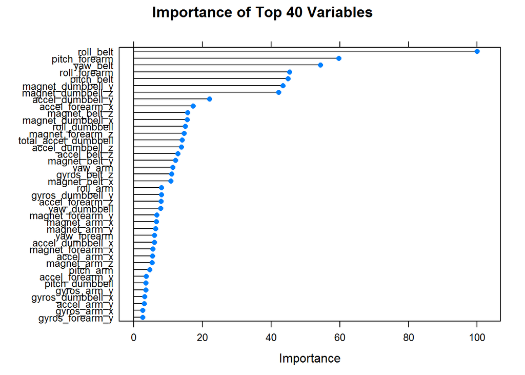

```r
varImpRF <- train(classe ~ ., data = Training, method = "rf")
varImpObj <- varImp(varImpRF)
# Top 40 plot
plot(varImpObj, main = "Importance of Top 40 Variables", top = 40)
```

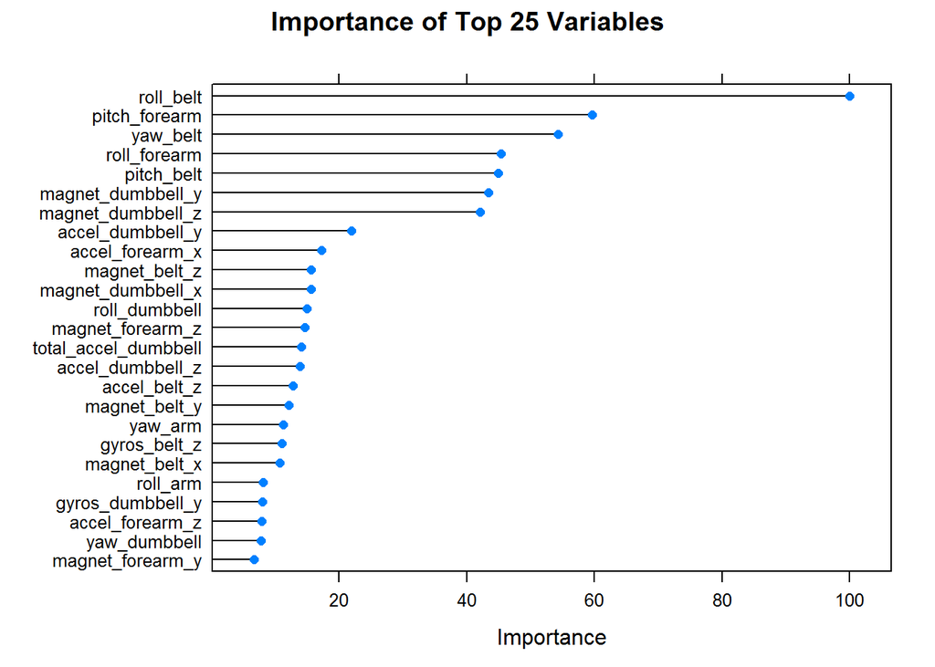

```r
plot(varImpObj, main = "Importance of Top 25 Variables", top = 25)
```

Conclusion

The Random Forest method worked well.

We then save the output to files according to instructions and post it to the submission page.

```r
answers <- as.vector(ptest)

pml_write_files = function(x) {
    n = length(x)
    for (i in 1:n) {
        filename = paste0("problem_id_", i, ".txt")
        write.table(x[i], file = filename, quote = FALSE, row.names = FALSE,
            col.names = FALSE)
    }
}

pml_write_files(answers)
```